# LDA - Wine Classification

## LDA - Wine Classification

**Importing the required libraries & packages**

```python
import numpy as np
import pandas as pd
import os
import seaborn as sns
import matplotlib.pyplot as plt
%matplotlib inline
from sklearn.model_selection import train_test_split
from sklearn.linear_model import LogisticRegression
from sklearn.preprocessing import StandardScaler
from sklearn.ensemble import ExtraTreesClassifier,RandomForestClassifier
from sklearn.decomposition import PCA
from sklearn.discriminant_analysis import LinearDiscriminantAnalysis as LDA
from catboost import CatBoostClassifier
from lightgbm import LGBMClassifier
from sklearn.metrics import accuracy_score,confusion_matrix,classification_report
import pickle
import warnings
warnings.filterwarnings('ignore')
```

**Changing The Default Working Directory Path & Reading the Dataset using Pandas Command**

```python
os.chdir('C:\\Users\\mural\\Documents\\Batch 74 Day 19')
df=pd.read_csv('Wine.csv')
```

## EDA:

**checking the null values in the all columns of the dataset**

```python
df.isnull().sum()
```

```
Alcohol                 0
Malic_Acid              0
Ash                     0
Ash_Alcanity            0
Magnesium               0
Total_Phenols           0
Flavanoids              0
Nonflavanoid_Phenols    0
Proanthocyanins         0
Color_Intensity         0
Hue                     0
OD280                   0
Proline                 0
Customer_Segment        0
dtype: int64
```

**Checking for the duplicate values of the given Dataset**

```python
df.duplicated().sum()
```

```
0
```

## Data Cleaning:

**Getting all the column names from the dataset**

```python
df.columns
```

```
Index(['Alcohol', 'Malic_Acid', 'Ash', 'Ash_Alcanity', 'Magnesium',
       'Total_Phenols', 'Flavanoids', 'Nonflavanoid_Phenols',
       'Proanthocyanins', 'Color_Intensity', 'Hue', 'OD280', 'Proline',
       'Customer_Segment'],
      dtype='object')
```

**Renaming the columns for the better readability using customize defined pandas function**

```python
def rename_columns(df,col_dict):
    return df.rename(columns=col_dict)
col_dict={'Malic_Acid':'Malic Acid','Ash_Alcanity':'Ash Alcanity',
       'Total_Phenols':'Total Phenols', 'Nonflavanoid_Phenols':'Nonflavanoid Phenols','Color_Intensity':'Color Intensity',
        'Customer_Segment':'Customer Segment'}
df=rename_columns(df,col_dict)
```

**Getting all the column names from the dataset after reanameing the columns**

```python
df.columns
```

```
Index(['Alcohol', 'Malic Acid', 'Ash', 'Ash Alcanity', 'Magnesium',
       'Total Phenols', 'Flavanoids', 'Nonflavanoid Phenols',
       'Proanthocyanins', 'Color Intensity', 'Hue', 'OD280', 'Proline',
       'Customer Segment'],
      dtype='object')
```

**Getting the unique values and its counts in the Customer Segment column from the dataset**

```python
df['Customer Segment'].value_counts()
```

```
2    71
1    59
3    48
Name: Customer Segment, dtype: int64
```

**Getting the correlation value from all the numeric columns from the independent variable using seaborn Heatmap & saving the PNG file**

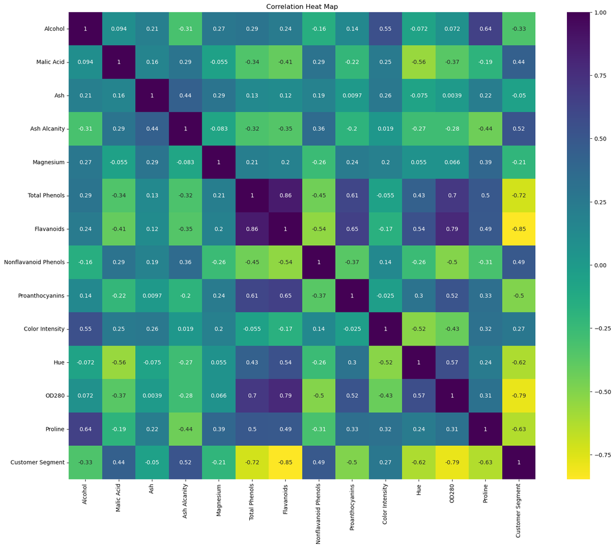

```python
plt.rcParams['figure.figsize']=20,15
sns.heatmap(df.corr(),cmap = 'viridis_r',annot=True,square=True)
plt.title('Correlation Heat Map')
plt.savefig('Correlation Heat Map.png')
plt.show()
```

**Assigning the dependent and independent Variable**

```python
x=df.iloc[:,:-1]
y=df.iloc[:,-1]
```

## Data Preprocessing:

**Standardizing the independent variable of the dataset**

```python
sc=StandardScaler()
x=sc.fit_transform(x)
```

```python
x_train,x_test,y_train,y_test=train_test_split(x,y,test_size=0.2,random_state=15)
```

**Fitting the Logistic Regressor Model with the train dependent and train independent variable and getting Accuracy score between the predicted values and dependent test dataset**

```python
log=LogisticRegression()
log.fit(x_train,y_train)
log_pred=log.predict(x_test)
print('Accuracy Score : {}%'.format(100* accuracy_score(y_test,log_pred)))
print('Confusion Matrix:\n',confusion_matrix(y_test,log_pred))
print('Classification Report:\n',classification_report(y_test,log_pred))
```

```
Accuracy Score : 100.0%
Confusion Matrix:
 [[12  0  0]
 [ 0 12  0]
 [ 0  0 12]]
Classification Report:
               precision    recall  f1-score   support

           1       1.00      1.00      1.00        12
           2       1.00      1.00      1.00        12
           3       1.00      1.00      1.00        12

    accuracy                           1.00        36
   macro avg       1.00      1.00      1.00        36
weighted avg       1.00      1.00      1.00        36
```

**Fitting the Random Forest Classifier Model with the train dependent and train independent variable and getting Accuracy score between the predicted values and dependent test dataset**

```python
rf=RandomForestClassifier(n_estimators=24,random_state=10)
rf.fit(x_train,y_train)
rf_pred=rf.predict(x_test)
print('Accuracy Score : {}%'.format(100* accuracy_score(y_test,rf_pred)))
print('Confusion Matrix:\n',confusion_matrix(y_test,rf_pred))
print('Classification Report:\n',classification_report(y_test,rf_pred))
```

```
Accuracy Score : 97.22222222222221%
Confusion Matrix:
 [[12  0  0]
 [ 0 12  0]
 [ 0  1 11]]
Classification Report:
               precision    recall  f1-score   support

           1       1.00      1.00      1.00        12
           2       0.92      1.00      0.96        12
           3       1.00      0.92      0.96        12

    accuracy                           0.97        36
   macro avg       0.97      0.97      0.97        36
weighted avg       0.97      0.97      0.97        36
```

**Fitting the Extra Trees Classifier Model with the train dependent and train independent variable and getting Accuracy score between the predicted values and dependent test dataset**

```python
et=ExtraTreesClassifier(n_estimators=24,random_state=10)
et.fit(x_train,y_train)
et_pred=et.predict(x_test)
print('Accuracy Score : {}%'.format(100* accuracy_score(y_test,et_pred)))
print('Confusion Matrix:\n',confusion_matrix(y_test,et_pred))
print('Classification Report:\n',classification_report(y_test,et_pred))
```

```
Accuracy Score : 100.0%
Confusion Matrix:
 [[12  0  0]
 [ 0 12  0]
 [ 0  0 12]]
Classification Report:
               precision    recall  f1-score   support

           1       1.00      1.00      1.00        12
           2       1.00      1.00      1.00        12
           3       1.00      1.00      1.00        12

    accuracy                           1.00        36
   macro avg       1.00      1.00      1.00        36
weighted avg       1.00      1.00      1.00        36
```

**Fitting the CatBoost Classifier Model with the train dependent and train independent variable and getting Accuracy score between the predicted values and dependent test dataset**

```python
cat=CatBoostClassifier(verbose=0)
cat.fit(x_train,y_train)
cat_pred=cat.predict(x_test)
print('Accuracy Score : {}%'.format(100* accuracy_score(y_test,cat_pred)))
print('Confusion Matrix:\n',confusion_matrix(y_test,cat_pred))
print('Classification Report:\n',classification_report(y_test,cat_pred))
```

```
Accuracy Score : 100.0%
Confusion Matrix:
 [[12  0  0]
 [ 0 12  0]
 [ 0  0 12]]
Classification Report:
               precision    recall  f1-score   support

           1       1.00      1.00      1.00        12
           2       1.00      1.00      1.00        12
           3       1.00      1.00      1.00        12

    accuracy                           1.00        36
   macro avg       1.00      1.00      1.00        36
weighted avg       1.00      1.00      1.00        36
```

**Fitting the LGBM Classifier Model with the train dependent and train independent variable and getting Accuracy score between the predicted values and dependent test dataset**

```python
lgb=LGBMClassifier()
lgb.fit(x_train,y_train)
lgb_pred=lgb.predict(x_test)
print('Accuracy Score : {}%'.format(100* accuracy_score(y_test,lgb_pred)))
print('Confusion Matrix:\n',confusion_matrix(y_test,lgb_pred))
print('Classification Report:\n',classification_report(y_test,lgb_pred))
```

```
Accuracy Score : 100.0%
Confusion Matrix:
 [[12  0  0]
 [ 0 12  0]
 [ 0  0 12]]
Classification Report:
               precision    recall  f1-score   support

           1       1.00      1.00      1.00        12
           2       1.00      1.00      1.00        12
           3       1.00      1.00      1.00        12

    accuracy                           1.00        36
   macro avg       1.00      1.00      1.00        36
weighted avg       1.00      1.00      1.00        36
```

**Processing the independent variable with principal component analysis to get the importance of all the columns in the independent variable and Getting the numeric value form the columns of the independent variable variable**

```python
pca=PCA()
pca_x=pca.fit_transform(x)
display(pca.explained_variance_ratio_)
```

```
array([0.36198848, 0.1920749 , 0.11123631, 0.0706903 , 0.06563294,
       0.04935823, 0.04238679, 0.02680749, 0.02222153, 0.01930019,
       0.01736836, 0.01298233, 0.00795215])
```

**Splitting the dependent and independent variable into PCA training and test dataset using train test split of the independent variable**

```python
pca_x_train,pca_x_test,y_train,y_test=train_test_split(pca_x,y,test_size=0.2,random_state=15)
```

**Fitting the Logistic Regressor Model with the dependent PCA train and independent PCA train variable and getting Accuracy score between the predicted values and dependent test dataset**

```python
pca_log=LogisticRegression()
pca_log.fit(pca_x_train,y_train)
pca_log_pred=pca_log.predict(pca_x_test)
print('Accuracy Score : {}%'.format(100* accuracy_score(y_test,pca_log_pred)))
print('Confusion Matrix:\n',confusion_matrix(y_test,pca_log_pred))
print('Classification Report:\n',classification_report(y_test,pca_log_pred))
```

```
Accuracy Score : 100.0%
Confusion Matrix:
 [[12  0  0]
 [ 0 12  0]
 [ 0  0 12]]
Classification Report:
               precision    recall  f1-score   support

           1       1.00      1.00      1.00        12
           2       1.00      1.00      1.00        12
           3       1.00      1.00      1.00        12

    accuracy                           1.00        36
   macro avg       1.00      1.00      1.00        36
weighted avg       1.00      1.00      1.00        36
```

**Fitting the Random Forest Classifier Model with the dependent PCA train and independent PCA train variable and getting Accuracy score between the predicted values and dependent test dataset**

```python
pca_rf=RandomForestClassifier(n_estimators=24,random_state=10)
pca_rf.fit(pca_x_train,y_train)
pca_rf_pred=pca_rf.predict(pca_x_test)
print('Accuracy Score : {}%'.format(100* accuracy_score(y_test,pca_rf_pred)))
print('Confusion Matrix:\n',confusion_matrix(y_test,pca_rf_pred))
print('Classification Report:\n',classification_report(y_test,pca_rf_pred))
```

```
Accuracy Score : 97.22222222222221%
Confusion Matrix:
 [[12  0  0]
 [ 1 11  0]
 [ 0  0 12]]
Classification Report:
               precision    recall  f1-score   support

           1       0.92      1.00      0.96        12
           2       1.00      0.92      0.96        12
           3       1.00      1.00      1.00        12

    accuracy                           0.97        36
   macro avg       0.97      0.97      0.97        36
weighted avg       0.97      0.97      0.97        36
```

**Fitting the Extra Trees Classifier Model with the dependent PCA train and independent PCA train variable and getting Accuracy score between the predicted values and dependent test dataset**

```python
pca_et=ExtraTreesClassifier(n_estimators=24,random_state=10)
pca_et.fit(pca_x_train,y_train)
pca_et_pred=pca_et.predict(pca_x_test)
print('Accuracy Score : {}%'.format(100* accuracy_score(y_test,pca_et_pred)))
print('Confusion Matrix:\n',confusion_matrix(y_test,pca_et_pred))
print('Classification Report:\n',classification_report(y_test,pca_et_pred))
```

```
Accuracy Score : 100.0%
Confusion Matrix:
 [[12  0  0]
 [ 0 12  0]
 [ 0  0 12]]
Classification Report:
               precision    recall  f1-score   support

           1       1.00      1.00      1.00        12
           2       1.00      1.00      1.00        12
           3       1.00      1.00      1.00        12

    accuracy                           1.00        36
   macro avg       1.00      1.00      1.00        36
weighted avg       1.00      1.00      1.00        36
```

**Fitting the CatBoost Classifier Model with the dependent PCA train and independentPCA train variable and getting Accuracy score between the predicted values and dependent test dataset**

```python
pca_cat=CatBoostClassifier(verbose=0)
pca_cat.fit(pca_x_train,y_train)
pca_cat_pred=pca_cat.predict(pca_x_test)
print('Accuracy Score : {}%'.format(100* accuracy_score(y_test,pca_cat_pred)))
print('Confusion Matrix:\n',confusion_matrix(y_test,pca_cat_pred))
print('Classification Report:\n',classification_report(y_test,pca_cat_pred))
```

```
Accuracy Score : 97.22222222222221%
Confusion Matrix:
 [[12  0  0]
 [ 1 11  0]
 [ 0  0 12]]
Classification Report:
               precision    recall  f1-score   support

           1       0.92      1.00      0.96        12
           2       1.00      0.92      0.96        12
           3       1.00      1.00      1.00        12

    accuracy                           0.97        36
   macro avg       0.97      0.97      0.97        36
weighted avg       0.97      0.97      0.97        36
```

**Fitting the LGBM Classifier Model with the dependent PCA train and independent PCA train variable and getting Accuracy score between the predicted values and dependent test dataset**

```python
pca_lgb=LGBMClassifier()
pca_lgb.fit(pca_x_train,y_train)
pca_lgb_pred=pca_lgb.predict(pca_x_test)
print('Accuracy Score : {}%'.format(100* accuracy_score(y_test,pca_lgb_pred)))
print('Confusion Matrix:\n',confusion_matrix(y_test,pca_lgb_pred))
print('Classification Report:\n',classification_report(y_test,pca_lgb_pred))
```

```
Accuracy Score : 94.44444444444444%
Confusion Matrix:
 [[12  0  0]
 [ 1 11  0]
 [ 0  1 11]]
Classification Report:
               precision    recall  f1-score   support

           1       0.92      1.00      0.96        12
           2       0.92      0.92      0.92        12
           3       1.00      0.92      0.96        12

    accuracy                           0.94        36
   macro avg       0.95      0.94      0.94        36
weighted avg       0.95      0.94      0.94        36
```

## Dimensional Reduction:

**Processing the independent variable with principal analysis of 2 components to get the importance of all the columns in the independent variable and Getting the numeric value form the columns of the independent variable after reducing the dimensional**

```python
pca1=PCA(n_components=2)
pca_x1=pca1.fit_transform(x)
display(pca1.explained_variance_ratio_)
```

```
array([0.36198848, 0.1920749 ])
```

**Splitting the dependent and independent variable into training and test dataset using train test split after reducing the dimensional**

```python
pca_x_train,pca_x_test,y_train,y_test=train_test_split(pca_x1,y,test_size=0.2,random_state=15)
```

**Fitting the Logistic Regressor Model with the train dependent and train independent variable and getting Accuracy score between the predicted values and dependent test dataset after reducing the dimensional**

```python
pca1_log=LogisticRegression()
pca1_log.fit(pca_x_train,y_train)
pca1_log_pred=pca1_log.predict(pca_x_test)
print('Accuracy Score : {}%'.format(100* accuracy_score(y_test,pca1_log_pred)))
print('Confusion Matrix:\n',confusion_matrix(y_test,pca1_log_pred))
print('Classification Report:\n',classification_report(y_test,pca1_log_pred))
```

```
Accuracy Score : 97.22222222222221%
Confusion Matrix:
 [[12  0  0]
 [ 1 11  0]
 [ 0  0 12]]
Classification Report:
               precision    recall  f1-score   support

           1       0.92      1.00      0.96        12
           2       1.00      0.92      0.96        12
           3       1.00      1.00      1.00        12

    accuracy                           0.97        36
   macro avg       0.97      0.97      0.97        36
weighted avg       0.97      0.97      0.97        36
```

**Fitting the Random Forest Classifier Model with the train dependent and train independent variable and getting Accuracy score between the predicted values and dependent test dataset after reducing the dimensional**

```python
pca1_rf=RandomForestClassifier(n_estimators=24,random_state=10)
pca1_rf.fit(pca_x_train,y_train)
pca1_rf_pred=pca1_rf.predict(pca_x_test)
print('Accuracy Score : {}%'.format(100* accuracy_score(y_test,pca1_rf_pred)))
print('Confusion Matrix:\n',confusion_matrix(y_test,pca1_rf_pred))
print('Classification Report:\n',classification_report(y_test,pca1_rf_pred))
```

```
Accuracy Score : 91.66666666666666%
Confusion Matrix:
 [[12  0  0]
 [ 2 10  0]
 [ 0  1 11]]
Classification Report:
               precision    recall  f1-score   support

           1       0.86      1.00      0.92        12
           2       0.91      0.83      0.87        12
           3       1.00      0.92      0.96        12

    accuracy                           0.92        36
   macro avg       0.92      0.92      0.92        36
weighted avg       0.92      0.92      0.92        36
```

**Fitting the Extra Trees Classifier Model with the train dependent and train independent variable and getting Accuracy score between the predicted values and dependent test dataset after reducing the dimensional**

```python
pca1_et=ExtraTreesClassifier(n_estimators=24,random_state=10)
pca1_et.fit(pca_x_train,y_train)
pca1_et_pred=pca1_et.predict(pca_x_test)
print('Accuracy Score : {}%'.format(100* accuracy_score(y_test,pca1_et_pred)))
print('Confusion Matrix:\n',confusion_matrix(y_test,pca1_et_pred))
print('Classification Report:\n',classification_report(y_test,pca1_et_pred))
```

```
Accuracy Score : 91.66666666666666%
Confusion Matrix:
 [[12  0  0]
 [ 2 10  0]
 [ 0  1 11]]
Classification Report:
               precision    recall  f1-score   support

           1       0.86      1.00      0.92        12
           2       0.91      0.83      0.87        12
           3       1.00      0.92      0.96        12

    accuracy                           0.92        36
   macro avg       0.92      0.92      0.92        36
weighted avg       0.92      0.92      0.92        36
```

**Fitting the CatBoost Classifier Model with the train dependent and train independent variable and getting Accuracy score between the predicted values and dependent test dataset after reducing the dimensional**

```python
pca1_cat=CatBoostClassifier(verbose=0)
pca1_cat.fit(pca_x_train,y_train)
pca1_cat_pred=pca1_cat.predict(pca_x_test)
print('Accuracy Score : {}%'.format(100* accuracy_score(y_test,pca1_cat_pred)))
print('Confusion Matrix:\n',confusion_matrix(y_test,pca1_cat_pred))
print('Classification Report:\n',classification_report(y_test,pca1_cat_pred))
```

```
Accuracy Score : 88.88888888888889%
Confusion Matrix:
 [[12  0  0]
 [ 2 10  0]
 [ 0  2 10]]
Classification Report:
               precision    recall  f1-score   support

           1       0.86      1.00      0.92        12
           2       0.83      0.83      0.83        12
           3       1.00      0.83      0.91        12

    accuracy                           0.89        36
   macro avg       0.90      0.89      0.89        36
weighted avg       0.90      0.89      0.89        36
```

**Fitting the LGBM Classifier Model with the train dependent and train independent variable and getting Accuracy score between the predicted values and dependent test dataset after reducing the dimensional**

```python
pca1_lgb=LGBMClassifier()
pca1_lgb.fit(pca_x_train,y_train)
pca1_lgb_pred=pca1_lgb.predict(pca_x_test)
print('Accuracy Score : {}%'.format(100* accuracy_score(y_test,pca1_lgb_pred)))
print('Confusion Matrix:\n',confusion_matrix(y_test,pca1_lgb_pred))
print('Classification Report:\n',classification_report(y_test,pca1_lgb_pred))
```

```
Accuracy Score : 88.88888888888889%
Confusion Matrix:
 [[12  0  0]
 [ 2 10  0]
 [ 0  2 10]]
Classification Report:
               precision    recall  f1-score   support

           1       0.86      1.00      0.92        12
           2       0.83      0.83      0.83        12
           3       1.00      0.83      0.91        12

    accuracy                           0.89        36
   macro avg       0.90      0.89      0.89        36
weighted avg       0.90      0.89      0.89        36
```

**Processing the independent variable with Linear Discriminant Analysis to get the importance of all the columns in the independent variable and Getting the numeric value form the columns of the independent variable variable**

```python
lda=LDA()
lda_x=lda.fit_transform(x,y)
display(lda.explained_variance_ratio_)
```

```
array([0.68747889, 0.31252111])
```

*Splitting the dependent and independent variable into training and test dataset using train test split*

```python
lda_x_train,lda_x_test,y_train,y_test=train_test_split(lda_x,y,test_size=0.2,random_state=15)
```

**Fitting the Logistic Regressor Model with the train dependent and train independent variable and getting Accuracy score between the predicted values and dependent test dataset after reducing the dimensional**

```python
lda_log=LogisticRegression()
lda_log.fit(lda_x_train,y_train)
lda_log_pred=lda_log.predict(lda_x_test)
print('Accuracy Score : {}%'.format(100* accuracy_score(y_test,lda_log_pred)))
print('Confusion Matrix:\n',confusion_matrix(y_test,lda_log_pred))
print('Classification Report:\n',classification_report(y_test,lda_log_pred))
```

```
Accuracy Score : 100.0%
Confusion Matrix:
 [[12  0  0]
 [ 0 12  0]
 [ 0  0 12]]
Classification Report:
               precision    recall  f1-score   support

           1       1.00      1.00      1.00        12
           2       1.00      1.00      1.00        12
           3       1.00      1.00      1.00        12

    accuracy                           1.00        36
   macro avg       1.00      1.00      1.00        36
weighted avg       1.00      1.00      1.00        36
```

**Fitting the Random Forest Classifier Model with the train dependent and train independent variable and getting Accuracy score between the predicted values and dependent test dataset after reducing the dimensional**

```python
lda_rf=RandomForestClassifier(n_estimators=24,random_state=10)
lda_rf.fit(lda_x_train,y_train)
lda_rf_pred=lda_rf.predict(lda_x_test)
print('Accuracy Score : {}%'.format(100* accuracy_score(y_test,lda_rf_pred)))
print('Confusion Matrix:\n',confusion_matrix(y_test,lda_rf_pred))
print('Classification Report:\n',classification_report(y_test,lda_rf_pred))
```

```
Accuracy Score : 100.0%
Confusion Matrix:
 [[12  0  0]
 [ 0 12  0]
 [ 0  0 12]]
Classification Report:
               precision    recall  f1-score   support

           1       1.00      1.00      1.00        12
           2       1.00      1.00      1.00        12
           3       1.00      1.00      1.00        12

    accuracy                           1.00        36
   macro avg       1.00      1.00      1.00        36
weighted avg       1.00      1.00      1.00        36
```

**Fitting the Extra Trees Classifier Model with the train dependent and train independent variable and getting Accuracy score between the predicted values and dependent test dataset after reducing the dimensional**

```python
lda_et=ExtraTreesClassifier(n_estimators=24,random_state=10)
lda_et.fit(lda_x_train,y_train)
lda_et_pred=lda_et.predict(lda_x_test)
print('Accuracy Score : {}%'.format(100* accuracy_score(y_test,lda_et_pred)))
print('Confusion Matrix:\n',confusion_matrix(y_test,lda_et_pred))
print('Classification Report:\n',classification_report(y_test,lda_et_pred))
```

```
Accuracy Score : 100.0%
Confusion Matrix:
 [[12  0  0]
 [ 0 12  0]
 [ 0  0 12]]
Classification Report:
               precision    recall  f1-score   support

           1       1.00      1.00      1.00        12
           2       1.00      1.00      1.00        12
           3       1.00      1.00      1.00        12

    accuracy                           1.00        36
   macro avg       1.00      1.00      1.00        36
weighted avg       1.00      1.00      1.00        36
```

**Fitting the CatBoost Classifier Model with the train dependent and train independent variable and getting Accuracy score between the predicted values and dependent test dataset after reducing the dimensional**

```python
lda_cat=CatBoostClassifier(verbose=0)
lda_cat.fit(lda_x_train,y_train)
lda_cat_pred=lda_cat.predict(lda_x_test)
print('Accuracy Score : {}%'.format(100* accuracy_score(y_test,lda_cat_pred)))
print('Confusion Matrix:\n',confusion_matrix(y_test,lda_cat_pred))
print('Classification Report:\n',classification_report(y_test,lda_cat_pred))
```

```
Accuracy Score : 100.0%
Confusion Matrix:
 [[12  0  0]
 [ 0 12  0]
 [ 0  0 12]]
Classification Report:
               precision    recall  f1-score   support

           1       1.00      1.00      1.00        12
           2       1.00      1.00      1.00        12
           3       1.00      1.00      1.00        12

    accuracy                           1.00        36
   macro avg       1.00      1.00      1.00        36
weighted avg       1.00      1.00      1.00        36
```

**Fitting the LGBM Classifier Model with the train dependent and train independent variable and getting Accuracy score between the predicted values and dependent test dataset after reducing the dimensional**

```python
lda_lgb=LGBMClassifier()
lda_lgb.fit(lda_x_train,y_train)
lda_lgb_pred=lda_lgb.predict(lda_x_test)
print('Accuracy Score : {}%'.format(100* accuracy_score(y_test,lda_lgb_pred)))
print('Confusion Matrix:\n',confusion_matrix(y_test,lda_lgb_pred))
print('Classification Report:\n',classification_report(y_test,lda_lgb_pred))
```

```
Accuracy Score : 94.44444444444444%
Confusion Matrix:
 [[12  0  0]
 [ 1 11  0]
 [ 0  1 11]]
Classification Report:
               precision    recall  f1-score   support

           1       0.92      1.00      0.96        12
           2       0.92      0.92      0.92        12
           3       1.00      0.92      0.96        12

    accuracy                           0.94        36
   macro avg       0.95      0.94      0.94        36
weighted avg       0.95      0.94      0.94        36
```

**Create the pickle files on the models with the highest Accuracy score with the model name**

```python
pickle.dump(lda_log,open('Logistic Regression.pkl','wb'))
pickle.dump(lda_rf,open('Random Forest.pkl','wb'))
pickle.dump(lda_et,open('Extra Trees.pkl','wb'))
pickle.dump(lda_cat,open('CatBoost.pkl','wb'))
```